# Parametrik olmayan istatistiksel yöntemler ödevi (6)

Ramazan Erduran, İlkay Şafak Baytar

06 Aralık 2021

# 6:

### Verilerin açıklaması:

Ödevimizin 1. sekmesinde elde ettiğimiz bağımsız **Gapminder** veri setinden incelemek üzere 3 kıta seçildi ve bu kıtalar arası fark olup olmadığna bakıldı:  
(**Amerika**, **Asya** ve **Avrupa**).

```r
gp_group_x %>%
  group_by(group) %>%
  get_summary_stats(lifeExp, type = "common")
```

```
## # A tibble: 3 x 11
##   group  variable     n   min   max median   iqr  mean    sd    se    ci
##   <chr>  <chr>    <dbl> <dbl> <dbl>  <dbl> <dbl> <dbl> <dbl> <dbl> <dbl>
## 1 ASIA   lifeExp     30  32.0  78.8   64.2 10.9   63.1 10.5   1.92  3.92
## 2 EUROPE lifeExp     30  48.1  78.5   72.2  5.25  71.5  6.09  1.11  2.27
## 3 USA    lifeExp     30  37.6  77.9   68.6  5.83  67.2  8.21  1.50  3.07
```

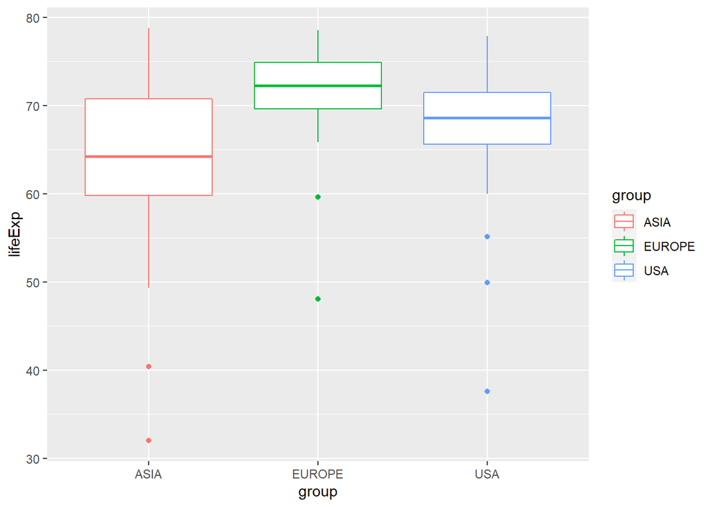

```r
ggplot(gp_group_x, aes(group, lifeExp, color= group)) + geom_boxplot()
```

### Hipotezlerin kurulması ve testin yapılması:

Boxplot ve özetleyici istatistiklerini gördüğümüz değişkenlerimizin hipotez testleri incelendi.  
Bu aşamada öncekilerde de olduğu gibi hipotezlerimizi kurup bu hipotezlere ilişkin Kruskall-Wallis Testi uygulandı:  
H0: D<sub>i</sub> = 0 (Kıtalar arası fark yoktur.)  
H1: D<sub>i</sub> $\neq$ 0 (Kıtalar arası fark vardır.)  
Alpha = 0.05  
için “**Kruskall-Wallis testi**” %5 yanılma düzeyiyle uygulanarak hipotezler test edildi:

```
##
##  Kruskal-Wallis rank sum test
##
## data:  gp_group_x$lifeExp by gp_group_x$group
## Kruskal-Wallis chi-squared = 16.223, df = 2, p-value = 0.0003001
```

### Hipotez sonuçları:

**Kruskall-Wallis** testinin sonucunda H0 hipotezimiz reddedildi ve kıtlar arası farklılık olduğu görüldü.  
Bir sonraki analizimizde ise bu farklılığın nerden geldiğini görmek için **Post-Hoc** testleri uygulanacak.

```r
gp_group_x %>%
  dunn_test(lifeExp~group, p.adjust.method = "bonferroni")
```

```
## # A tibble: 3 x 9
##   .y.     group1 group2    n1    n2 statistic         p    p.adj p.adj.signif
## * <chr>   <chr>  <chr>  <int> <int>     <dbl>     <dbl>    <dbl> <chr>
## 1 lifeExp ASIA   EUROPE    30    30      3.98 0.0000681 0.000204 ***
## 2 lifeExp ASIA   USA       30    30      1.47 0.141     0.423    ns
## 3 lifeExp EUROPE USA       30    30     -2.51 0.0121    0.0362   *
```

### Post-Hock test sonuçları:

Hipotezlerimiz **Krusall-Wallis** testi ile test edildi ve yorum olarak:  
“%95 güvenle söylenebilir ki kıtalar arası farklılık vardır” yorumu yapıldı.  
Çoklu karşılaştırma sorunlarını ortadan kaldırmak için **“Bonferroni”** düzeltmesi ile yaptığımız **Duncann** testinin sonucunda ise:  
Asya ve Avrupa ………… Fark anlamlıdır  
Asya ve Amerika ………… Fark anlamlı değildir  
Avrupa ve Amerika ………… Fark anlamlıdır  
Çıktılarını kullanarak: “Kıtalar arası farklılığın **Avrupa’dan (`EUROPE`)** dan kaynaklandığı %95 güven düzeyiyle söylenebilir.”